# Statistical Tests for Comparison of Two Groups

Zeynel Cebeci, A. Firat Ozdemir, Engin Yildiztepe

3 May 2025

# 1 Introduction

This vignette offers an in-depth exploration of methodologies and statistical tests for comparing two independent or paired groups using the package `groupcompare` in R. It covers a range of techniques, including parametric and non-parametric tests, permutation methods, and bootstrap approaches. By simulating normal distributed data for two groups, the document provides a step-by-step guide to data preparation, visualization, and analysis. The centerpiece of the vignette is the core function `groupcompare`, which is employed to compare group statistics and interpret the results thoroughly. The vignette further highlights the adaptability of the statistical tests, allowing users to tailor them to meet specific statistics and unique analytical scenarios.

# 2 Required Packages and Data Sets

The recent version of the package from CRAN is installed with the following command:

```r
install.packages("groupcompare", dep=TRUE)
```

If you have already installed ‘`groupcompare`’, you can load it into R working environment by using the following command:

```r
library("groupcompare")
```

## 2.2 Data sets

```r
 set.seed(30) # For reproducibility purpose
 grp1 <- ghdist(25, 50, 2, g=0, h=0)
 grp2 <- ghdist(25, 50, 2, g=0, h=0)
 ds1 <- data.frame(grp1=grp1, grp2=grp2)
 head(ds1)
```

```
##       grp1     grp2
## 1 47.42296 47.80720
## 2 49.30462 48.93156
## 3 48.95674 47.15759
## 4 52.54695 47.51452
## 5 53.64904 50.46387
## 6 46.97738 46.54960
```

```r
 # Data in long format
 ds2 <- wide2long(ds1)
 head(ds2)
```

```
##        obs group
## 1 47.42296  grp1
## 2 49.30462  grp1
## 3 48.95674  grp1
## 4 52.54695  grp1
## 5 53.64904  grp1
## 6 46.97738  grp1
```

# 3 Data Visualization

For statistical tests, data visualization is performed before the analysis to provide insights about the structure or distribution of the data. In the comparison of two groups using parametric tests such as the *t*-test, visualization provides preliminary information on whether the assumptions of the test are satisfied. The `bivarplot` function in the following code chunk facilitates the examination and comparison of group data using various plots.

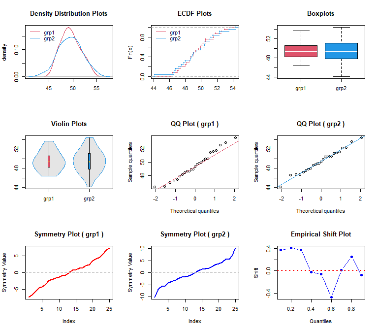

```r
bivarplot(ds2)
```

# 4 Statistical Tests

The `groupcompare` function of the package, given an example of its usage in the following code chunk, compares the groups in the dataset using various statistical tests and returns the results. In the code chunk below, `statistic` is the name of the function that calculates and returns the differences in the statistics of the groups to compare them. In the example, `calcstatdif` is a function that calculates and returns the differences between group means, medians, interquartile ranges, and variances. Among its arguments, `cl` shows the confidence level, and `R` shows the number of resampling for permutation tests and bootstrap. In the function call `qtest` describes whether a quantile comparison test is also performed. In the example, it is set to `FALSE`. Among other arguments, `plots` indicates whether to generate the visualization of the group values as shown in the example above, while setting `verbose` to `TRUE` shows all the steps and analysis results in detail during the run. If the results of the analysis are to be saved, setting the `out` argument to `TRUE` saves the results in a file named `*dataframe_name*.txt`.

```r
results <- groupcompare(ds2, alternative="two.sided", cl=0.95, qtest=FALSE,
R=1000, plots=FALSE, out=FALSE, verbose=TRUE)
```

```
##       n      min      max     mean        se   trmean      med      mad
## grp1 25 46.33202 53.64904 49.53190 0.4049744 49.47496 49.30462 1.844974
## grp2 25 44.13116 54.33940 49.48523 0.4794747 49.45577 49.36481 2.517676
##             skew       kurt winsmean hubermean    range      iqr       sd
## grp1  0.26693039 -0.8987614 49.52091  49.44165  7.31702 2.373299 2.024872
## grp2 -0.01674843 -0.5040030 49.46296  49.44833 10.20824 3.255761 2.397374
```

```
##           P10      P20      P30      P40      P50      P60      P70      P80
## grp1 47.05897 47.84736 48.51477 48.83583 49.30462 49.91318 50.47382 51.52705
## grp2 46.68574 47.44314 48.13850 48.85853 49.36481 50.38383 50.45924 51.27453
##           P90
## grp1 52.23230
## grp2 52.31066
```

```
##
##  Shapiro-Wilk normality test
##
## data:  grp1
## W = 0.97285, p-value = 0.7176
##
##
##  Shapiro-Wilk normality test
##
## data:  grp2
## W = 0.98871, p-value = 0.9911
```

```
##   p.value
## 0.4356048
```

```
##
##  Two Sample t-test
##
## data:  grp1 and grp2
## t = 0.074356, df = 48, p-value = 0.941
## alternative hypothesis: true difference in means is not equal to 0
## 95 percent confidence interval:
##  -1.215237  1.308571
## sample estimates:
## mean of x mean of y
##  49.53190  49.48523
```

```
##
##  Wilcoxon rank sum exact test
##
## data:  grp1 and grp2
## W = 314, p-value = 0.9847
## alternative hypothesis: true location shift is not equal to 0
```

```
##  MEAN   MED   IQR   VAR  SKEW  KURT
## 0.954 1.000 0.408 0.402 0.601 0.606
```

```
## mean.bca.lower mean.bca.upper  med.bca.lower  med.bca.upper
##      -1.065792       1.219093      -1.731947       1.563317
```

The `descriptives` component in the result object is a data frame containing common descriptive statistics related to the two compared groups. The `inference` component of the result list contains the statistics and significance values related to appropriate group comparison tests.

```r
results$descriptives
```

```
##       n      min      max     mean        se   trmean      med      mad
## grp1 25 46.33202 53.64904 49.53190 0.4049744 49.47496 49.30462 1.844974
## grp2 25 44.13116 54.33940 49.48523 0.4794747 49.45577 49.36481 2.517676
##             skew       kurt winsmean hubermean    range      iqr       sd
## grp1  0.26693039 -0.8987614 49.52091  49.44165  7.31702 2.373299 2.024872
## grp2 -0.01674843 -0.5040030 49.46296  49.44833 10.20824 3.255761 2.397374
```

```r
results$meanstest
```

```
##          t        t.p
## 0.07435647 0.94103576
```

```r
results$inference
```

```
## [1] "According to the t-test, the difference of the group means is  not significantly different from zero, t(25,25)=0.074, p=0.941."
```

# 5 Results and Interpretation

The `meanstest` component in the result includes statistics related to group comparison tests and the significance probability value for the hypothesis test conducted at *alpha = 1-cl* Type I error. In the output includes `test` includes the test result used at inference. Specifically, if the assumptions of the parametric *t*-test are met, the *t*-test results are returned; if not, non-parametric test results are provided. If the distributions are not similar, results from bootstrap and permutation tests are presented.

In the output, `t` and `t.p` are the *t*-statistic and significance probability for the *t*-test, respectively; `W` and `W.p` are the *W*-statistic and significance probability for the relevant non-parametric test, respectively. Looking at the results obtained. In the results, `per.mean` and `per.med` show the *p*-values determined with the permutation test for the mean and median, respectively. In the output, `mean.bca.lower` and `mean.bca.upper`, along with `med.bca.lower` and `med.bca.upper`, represent the lower and upper limits of the confidence intervals calculated by the *BCa* method at the `cl` confidence level for the mean and median, respectively.

# 6 Tests for Statistics Other Than the Mean

With the `groupcompare` function of the package, it is also possible to test whether the differences in statistics other than the mean and median are significant. To do this, an external R function that calculates the differences for the interested statistics should be coded and assigned to the `statistic` argument of the function. Once this function code is loaded into the global environment in the R environment and its name is assigned to the statistic argument, group comparisons for the desired statistics can be performed.

Essentially, the `calcstatdif` function in the package is also such a function. This function is used for permutation and bootstrap tests in addition to the *t*-test and non-parametric test for the mean and median. The function also applies permutation and bootstrap tests for differences in the interquartile range (`IQR`) and variance (`VAR`) of the groups, alongside the mean and median. To see these outputs, it is sufficient to set the `verbose` argument of the `groupcompare` function to `TRUE` as done in the function call of the example above. In the output, `MEAN`, `MED`, `IQR`, `VAR`, `SKEW` and `KURT` show the *p*-values from permutation test and bootstrap confidence intervals for the differences in the mean, median, interquartile range, variance, skewness and kurtosis, respectively. Additionally, it should be noted that these results can be saved to a file in the working directory by setting the `out` argument to `TRUE`.

In order to make a comparison in terms of quantiles of the groups, the `qtest` argument of the `groupcompare` function should be set to `TRUE`, and pass the quantiles you want to compare as a percentile vector to the `q` argument.